# El potencial transfronterizo de las especies marinas de importancia pesquera del mundo

Juliano Palacios-Abrantes, Gabriel Reygondeau, Colette C.C. Wabnitz and William W.L. Cheung

10/2020

- **NOTA: esta es una traducción al español del artículo:** *The transboundary nature of the world’s exploited marine species*, escrito por Juliano Palacios-Abrantes, Gabriel Reygondeau, Colette C.C. Wabnitz y William W.L. Cheung y que se puede encontrar en la siguiente [liga](https://www.nature.com/articles/s41598-020-74644-2). No cuenta con la sección de métodos traducida.
- **Forma de Citar**: Palacios-Abrantes, J., Reygondeau, G., Wabnitz, C. C. C., and Cheung, W. W. L., 2020. The transboundary nature of the world’s exploited marine species. *Scientific Reports*, 10 (1), 415–12. DOI: 10.1038/s41598-020-74644-2

Descargar Artículo en Español

# Resumen

Es frecuente que los límites espaciales de las herramientas de manejo ambiental y la distribución de especies no coincidan como sucede en el caso de especies marinas que cruzan múltiples Zonas Económicas Exclusivas (ZEE). Este tipo de movimiento representa un desafío para el manejo pesquero, ya que las políticas públicas tienden a enfocarse en el nivel nacional. Sin embargo, es necesario establecer colaboraciones internacionales para maximizar los beneficios ecológicos, sociales y económicos a largo plazo obtenidos con la captura de especies marinas compartidas. En este artículo se combinó la distribución de especies con la delimitación espacial de las ZEE para identificar el número de especies marinas explotadas comercialmente que son compartidas por naciones vecinas (especies transfronterizas). Los resultados revelaron que el 67% de las especies analizadas pertenecen a esa categoría (n = 633). Entre 2005 y 2014, las pesquerías que tenían como objetivo estas especies y que operaban dentro de las ZEE mundiales capturaron un promedio de 48 millones de toneladas por año, lo que equivale a un promedio de 77 mil millones de dólares en ingresos anuales por pesca. Durante este tiempo, más del 90% de las capturas y beneficios económicos de algunos países fue resultado de unos pocos recursos compartidos. Así mismo, se demuestra que las capturas de especies transfronterizas están disminuyendo a un ritmo mayor que las no transfronterizas. Este estudio tiene implicaciones directas para el manejo pesquero de dichas especies, destacando la necesidad de fortalecer una cooperación internacional eficiente y equitativa.

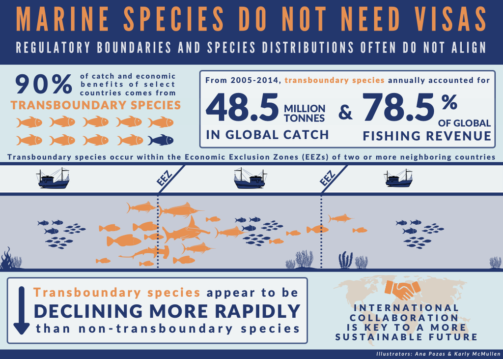

**Número de especies transfronterizas y su contribución a las capturas nacionales.**  
**DOI: 10.1038/s41598-020-74644-2**

# Introducción

La distribución global de las especies marinas no está limitada por fronteras antropogénicas, sino por factores bióticos y abióticos, así como la historia evolutiva de las especies<sup>1,2</sup>. Una especie puede estar ampliamente distribuida (cosmopolita) o limitada a una zona en particular (endémica)<sup>2</sup>. Sin embargo, el manejo pesquero se basa en la definición de “poblaciones” o “stocks pesqueros” que en la mayoría de los casos están sujetas a límites espaciales antropogénicos, que a menudo no corresponden a los biológicos<sup>3,4</sup>. Este es el caso de las Zonas Económicas Exclusivas (ZEE) creadas en virtud de la Parte V de la Convención de las Naciones Unidas sobre el Derecho del Mar (CONVEMAR). A principios de los años 80, CONVEMAR amplió las fronteras políticas de las naciones costeras de 12 a 200 millas náuticas para otorgar derechos de propiedad sobre los recursos marinos<sup>5</sup>. Sin embargo, los límites de las ZEE atravesaron las áreas de distribución de muchas especies marinas, creando poblaciones compartidas entre naciones<sup>6</sup>.

Las poblaciones compartidas se pueden clasificar en tres categorías no exclusivas; “transfronterizas” (*transboundary* en inglés): poblaciones que cruzan las ZEE de dos o más estados costeros; “transzonales” (*straddling* en inglés): poblaciones que cruzan las ZEE vecinas y el alta mar adyacente; y poblaciones “altamente migratorias” (*highly migratory* en inglés) que se adentran en alta mar están presentes en ZEEs que no son vecinas (principalmente atunes)<sup>7</sup>. El presente estudio se centra en la naturaleza “transfronteriza” de las especies compartidas explotadas por las pesquerías que operan dentro de las ZEEs mundiales. Estudios empíricos apoyan la teoría de que el manejo pesquero de recursos compartidos es complejo y puede reducir la eficiencia de políticas públicas para alcanzar los objetivos propuestos<sup>8</sup>. Por ejemplo, variaciones en la distribución de especies compartidas han provocado conflictos internacionales debido a modificaciones en la proporción de captura<sup>8</sup>, así como complicaciones en la asignación de cuotas o la incorporación de nuevos países a la pesquería<sup>9</sup>. Asimismo, es probable que el cambio climático exacerbe dichos conflictos, al presentar nuevos desafíos para las relaciones internacionales<sup>10</sup> y para el manejo pesquero<sup>11</sup>. Por lo tanto, es necesario tener un conocimiento preciso de la distribución de las especies de peces transfronterizas y transzonales para lograr un manejo sustentable de las pesquerías que explotan dichos recursos, particularmente bajo un contexto de cambio climático.

Cuarenta años después de la adopción formal de la CONVEMAR y el subsecuente Acuerdo de las Naciones Unidas en 1995 para la cooperación en la gestión de recursos transzonales y altamente migratorios, aún no existen estimaciones precisas del número de especies marinas pescadas que son compartidas por naciones vecinas<sup>12</sup>. Una primera estimación que utilizó un número limitado de datos biogeográficos, concluyó que existían entre 500 y 1500 poblaciones transfronterizas explotadas<sup>13</sup>. Recientemente, una revisión bibliográfica identificó 344 taxones compartidos y destacó su contribución histórica a la pesca mundial<sup>14</sup>. Si bien estos estudios ofrecen una primera estimación global de poblaciones de especies transfronterizas, ninguno de ellos consideró las características biogeográficas de las especies. El presente estudio hipotiza que dichas limitaciones metodológicas dieron como resultado una subestimación del número de poblaciones transfronterizas y de su contribución a las capturas y a los ingresos mundiales derivados de la pesca. Por ello, el objetivo fue incorporar principios de biogeografía para estimar el número de especies marinas explotadas que son compartidas por países vecinos. Asimismo, se determinó la contribución de estas especies a las capturas mundiales y regionales, así como a los ingresos monetarios producto de la pesca. Finalmente, las especies fueron clasificadas de acuerdo con las tendencias de captura de sus pesquerías y a sus preferencias de hábitat para encontrar diferencias entre ellas.

Para ello, se combinó el área de distribución de 938 especies marinas de valor comercial con el de 280 ZEEs de 198 países costeros. Las especies analizadas fueron responsables por 96,5% (en promedio) de las capturas de las ZEE mundiales entre 2005 y 2014 (ver Métodos). Las especies presentes en una ZEE fueron consideradas como un “*stock* pesquero” y no como unidades genética o morfológicamente distintas<sup>2</sup>, debido a la falta de información biológica al nivel poblacional para casi todas las especies incluidas en este estudio<sup>14</sup>. Si bien reconocemos que una especie puede tener múltiples poblaciones dentro de una misma ZEE, varias pesquerías al interior de un país o de una ZEE se gestionan al nivel de especie (o incluso de múltiples especies), y no en términos de población. Por ejemplo, tanto el camarón (e.g., *Litopenaeus stylirostris* o *Farfantepenaeus californiensis*) de la costa del Pacífico de México,<sup>15</sup> como el tiburón martillo (*Sphyrna zygaena*) de Perú,<sup>16</sup> se manejan al nivel de especie, pero incluyen múltiples poblaciones explotadas por las pesquerías de cada país. Asimismo, estudios recientes demuestran que las poblaciones de peces están conectadas a través de la dispersión de larvas<sup>17</sup> y la migración de adultos<sup>18–20</sup>, aunque cabe mencionar que existe gran incertidumbre respecto a dicha conectividad aen diferentes etapas del crecimiento de un individuo<sup>21,22</sup>. En el presente análisis se identificaron las especies compartidas entre ZEE vecinas, pero no su distribución extendida (por ejemplo, no se incluyó el área d alta mar adyacente a las ZEEs). Para ello se emplearon múltiples fuentes de datos, incluyendo ocurrencia y captura, así como modelos de distribución de especies. Sólo se consideró que una especie estaba presente en tiempo y espacio si todas las fuentes de datos coincidían (ver Métodos)

# Resultados y discusión

Se identificaron 633 especies transfronterizas explotadas en todo el mundo (67,5% de las 938 especies analizadas), casi el doble de estimaciones anteriores<sup>14</sup>. Entre 2005 y 2014, las flotas nacionales capturaron un promedio anual de 48,5 millones de toneladas d estas especies dentro de las ZEEs, lo que representa el 82,3% de las capturas derivadas de las ZEEs identificadas por el *Sea Around us* al nivel de especie (Fig. 1a). Estas capturas generaron un promedio anual de 77.591 millones de dólares estadounidenses en ingresos por pesca (78,5% de los ingresos por pesca mundiales) durante el mismo período. Dichos resultados son considerablemente mayores que los 34,2 millones de toneladas en capturas y 40.187 millones de dólares en ingresos obtenidos por la pesca de poblaciones compartidas previamente estimados<sup>14</sup>. Al evaluar las capturas de especies transfronterizas utilizando datos consistentes con estudios anteriores (datos mundiales de la FAO de 2006), las 633 especies identificadas aquí representaron 40,4 millones de toneladas de capturas anuales (es decir, un 18% más de lo estimado previamente). Dichos resultados sugieren que la contribución de las especies transfronterizas a la captura e ingresos por concepto de pesca mundial podría haber sido subestimada anteriormente debido a fallas en la comprensión general del potencial transfronterizo de las especies marinas. Las 305 especies no transfronterizas (denominadas aquí especies “discretas”, ver métodos) representaron una proporción mucho menor de las capturas e ingresos totales: 2,8 millones de toneladas y 4.282 millones de dólares anuales respectivamente, en promedio, entre 2005 y 2014. Estos resultados enfatizan la importancia de las especies transfronterizas al nivel mundial.

[Figura 1. Número de especies transfronterizas y su contribución a las capturas e ingresos de la pesca mundial. a) El número de especies e ingresos por pesca se representan mediante el código de colores de las ZEE y los polígonos terrestres, respectivamente; b) Contribución de las especies transfronterizas a los ingresos regionales (izquierda) y la captura (derecha). Regiones clasificadas según las subregiones de Naciones Unidas. Puntos = media $\pm$ sd. Ingresos en USD reales de 2010](https://www.nature.com/articles/s41598-020-74644-2/figures/1)

De acuerdo con los criterios de categorización, una especie se puede distribuir en múltiples ZEE, pero sólo poderá ser clasificada como transfronteriza en un sub-conjunto de ZEE (ver Métodos). Por ejemplo, la distribución de anchoveta peruana (*Engraulis ringens*) abarca las ZEE de Perú, Chile y Ecuador; sin embargo, nuestro estudio solo consideró transfronterizas las poblaciones de Perú y Chile<sup>23</sup>. Apenas una pequeña proporción del rango de distribución compartido de la anchoveta se encuentra en aguas ecuatorianas, razón por la cual ella no cumple con los criterios para ser considerada como una población transfronteriza. Situaciones como la de la anchoveta peruana en aguas ecuatorianas son habituales entre las especies transfronterizas identificadas en este estudio. En general, 590 de las 633 especies transfronterizas tienen poblaciones en las ZEE que no cumplen con los criterios para ser consideradas como poblaciones transfronterizas. La contribución promedio anual de todas las poblaciones no transfronterizas a la pesca (por ejemplo, la captura de anchoveta de Ecuador) entre 2005 y 2014 fue de 10,8 millones de toneladas, lo que representa 19 243 millones de dólares en ingresos producto de la pesca durante el mismo período.

En términos económicos, se constató que las especies transfronterizas son particularmente importantes para las regiones de América del Norte (ingreso promedio por país = 4,680 $ pm $ 6,000 millones de dólares) y Asia Oriental (3,779 $ pm $ 3,093 millones de dólares) (Fig. 1b). Los ingresos por país generados por la pesca de especies transfronterizas en estas dos regiones son significativamente diferentes a los obtenidos en otras regiones (ANOVA de una vía; *DF* (16,165) = 5.081, *p* <0.001, $ alpha $ = 0.05). China (USD 7.284 millones) y Estados Unidos (11.604 millones de dólares) aportaron el 55% y el 82% de los ingresos medios anuales de 2005 a 2014 en Asia oriental y América del Norte, respectivamente. Además de China y Estados Unidos, Rusia (USD 7.379 millones), Perú (USD 6.044 millones) y Japón (USD 3.907 millones) se encuentran entre los cinco países con mayores ingresos pesqueros generados por especies transfronterizas entre 2005 y 2014 (Fig. 1a). Estas cinco naciones fueron responsables por el 41% de los ingresos pesqueros mundiales anuales de especies transfronterizas.

Se determinaron las tendencias de captura de cada especie dentro de cada ZEE, clasificándolas como “aumentando” (Categoría A), “constante” (Categoría B) o “disminuyendo” (Categoría C) (Fig. 3). Si bien estudios previos han demostrado que las tendencias de captura pueden ser utilizadas para inferir si una población está siendo explotada de manera sustentable, está en recuperación, o se encuentra sobreexplotada o colapsada<sup>27</sup>, varios factores pueden influir en el estado de un *stock* pesquero. Por lo tanto, la intención aquí es examinar en qué casos las tendencias de captura de especies transfronterizas difirieron de las de especies no transfronterizas entre 2005 y 2010, en relación con la captura histórica desde 1951 (Ver métodos). Encontramos diferencias significativas en todas las categorías de tendencias de captura para especies transfronterizas (ANOVA de una vía, *Df* (2,459) = 47.94, *p* <0.001, $\alpha$ = 0.05; prueba post hoc de Tukey *p* $\leq$ 0,001) pero no en el caso de especies discretas (ANOVA de una vía, *Df* (2,106) = 1,885, *p* = 0,157; $\alpha$ = 0,05). También encontramos diferencias significativas en las tendencias de captura al comparar directamente categorías de especies transfronterizas con no-transfronterizas (MANOVA, *Df* (2,459) = 19,001, *p* <0,001). En general, las pesquerías de especies transfronterizas de un solo país tienen menos probabilidad de disminuir que aquellas en que países vecinos pescan la especie compartida (Tabla complementaria S2).

[Figura 3. Número de especies transfronterizas por categoría de captura. Categoría A, aumento de la captura; Categoría B, captura constante; Categoría C, disminución de la captura. “No Category” refleja especies con menos de 10 años de datos de captura y/o menos de 5 años consecutivos de datos de captura.](https://www.nature.com/articles/s41598-020-74644-2/figures/3)

Análisis empíricos previos sugieren que, en la mayoría de los casos, las pesquerías de especies transfronterizas producen mejores resultados en términos de capturas cuando las naciones cooperan en su manejo<sup>8</sup>. Sin embargo, el manejo compartido es un proceso complejo<sup>28</sup> y en algunos casos específicos puede no ser la mejor estrategia para los países involucrados<sup>29</sup>. Ejemplos de gestión conjunta exitosa incluyen acuerdos entre Noruega y Rusia para el manejo del bacalao del Atlántico (*Gadus morhua*)<sup>30</sup> y entre Namibia y Sudáfrica para el manejo de la merluza (*Merluccius spp*)<sup>31</sup>. A su vez, la falta de colaboración en el manejo de stocks pesqueros compartidos puede amenazar su sostenibilidad, reducir la rentabilidad de la pesquería y provocar conflictos entre naciones vecinas<sup>9,32</sup>.

La pesca de especies transfronterizas es importante para varios países con histórico de conflictos relacionados con la pesca, como es el caso de Canadá, Estados Unidos, Rusia y miembros de la Unión Europea (UE)<sup>33</sup>. Por ejemplo, desde 2007 la UE, Noruega, Islandia y las Islas Feroe (Dinamarca) han estado en desacuerdo sobre el tamaño y la distribución relativa de las cuotas de captura para la caballa del Atlántico (*Scomber scombrus*), debido a una alteración en la distribución de la especie provocada por el cambio climático<sup>9</sup>. La caballa del Atlántico es una especie transfronteriza que se adentra en alta mar y cuya pesca, entre 2005 y 2014,significó un promedio anual de 598,4 mil toneladas (8,19%) en capturas totales y USD 850,2 millones (7,17%) en ingresos a los países involucrados en la disputa. Se espera que el cambio climático continúe alterando la distribución de los stocks pesqueros y la proporción de dicha distribución entre países vecinos, lo que resultará en la aparición de nuevas especies transfronterizas<sup>10</sup> y la desaparición de otras<sup>34</sup>. Explorar con mayor detalle los efectos del cambio climático en la distribución de especies transfronterizas es clave para desarrollar métodos de adaptación que puedan anticipar los impactos negativos a la sostenibilidad pesquera. Por ejemplo, identificar cambios en la proporción de la distribución de especies transfronterizas entre ZEEs vecinas, el momento en el tiempo en el cual se producirán dichos cambios<sup>35</sup> y sus consecuencias económicas, son elementos que pueden ayudar al desarrollo de tratados internacionales que busquen prevenir y enfrentar los efectos del cambio climático<sup>36</sup>.

La mayoría de las especies de peces marinos se encuentran en aguas tropicales y subtropicales<sup>2,37</sup>. Desde especies altamente migratorias asociadas con ecosistemas pelágico-oceánicos como los atunes (*Thunnus sp.*), hasta especies menos móviles como el jurel (*Seriola dumerili*), que son relacionadas con ecosistemas arrecifales, o especies que se encuentran en ecosistemas demersales, como la dorada (*Sparus aurata*). El número de ZEEs donde la especie ocurre como transfronteriza es significativamente mayor (ANOVA unidireccional; *DF* (5.597) = 53.82, *p* <0.001, $\alpha$ = 0.05; prueba post hoc de Tukey * p * <0.05) para especies asociadas a ecosistemas pelágico-oceánicos con una media de 40 ZEEs por especie. La media de los demás ecosistemas (p.ej. bénticos o arrecifales) es cercana o menor a 20, ya que muchas de las especies asociadas a estos ecosistemas tienen una distribución más limitada o son menos móviles (Fig. 4a). Este resultado está probablemente influenciado por la amplia distribución de las especies con preferencia por ecosistemas pelágico-oceánicos, ya que varias de ellas son altamente migratorias y atraviesan las ZEEs de países separados por alta mar. Por lo tanto, el número de ZEEs no vecinas que comparten una especie altamente migratoria puede ser superior a 100, como en el caso del atún ojo grande o patudo (*Thunnus obesus*) (Fig. 4a). Debido a sus amplios padrones de migración y presencia en áreas más allá de las jurisdicciones nacionales, muchas especies altamente migratorias son manejadas por Organizaciones Regionales de Manejo Pesquero (OROP o RFMO, por sus siglas en inglés).

[Figura 4. Número de ZEEs compartidas por especies transfronterizas. a) Número de ZEEs por especie, organizadas de acuerdo con la preferencia del ecosistema según lo definido por FishBase. Se muestran sólo especies que comparten > 20 ZEEs. b) Captura promedio entre 2005 y 2014 para los cinco principales países que capturan las cinco especies compartidas más frecuentes por preferencia de ecosistema. Téngase en cuenta que podría haber > 5 especies debido a valores de intercambio similares. La categoría Otros consiste en especies que no tienen una clasificación de preferencia de ecosistema en FishBase](https://www.nature.com/articles/s41598-020-74644-2/figures/4)

Muchas especies transfronterizas son compartidas por numerosas ZEEs vecinas, a pesar de no ser consideradas altamente migratorias (p.ej., el pez aguja *Belone belone*) (Fig. 4a). Además, múltiples meta-poblaciones están conectadas a través de la dispersión de larvas con poblaciones “origen” sustentando poblaciones “sumideros” a miles de kilómetros de distancia<sup>17</sup>. Sin embargo, es importante reconocer que existe un grado considerable de incertidumbre con respecto a la conectividad de las poblaciones marinas en diferentes etapas de desarrollo individual, desde larvas<sup>21</sup> hasta adultos<sup>22</sup>. Las ZEEs de regiones de arrecifes a menudo comparten múltiples especies mediante de la conectividad de larvas<sup>38</sup> y el movimiento de adultos<sup>18</sup>, a pesar de que el número total de especies compartidas es bajo en esas regiones (Fig. 4a). Áreas marinas protegidas transfronterizas han sido identificadas como posibles herramientas de gestión pesquera y conservación en algunas regiones arrecifales como el Caribe y el Océano Índico Occidental<sup>18,39</sup>. El manejo eficiente de especies arrecifales es fundamental para muchas comunidades costeras, ya que estas tienden a depender en gran medida de la pesca de subsistencia para la seguridad alimentaria y nutricional, así como para sus medios de vida<sup>40,41</sup>. Así, varios países con las mayores capturas de especies transfronterizas asociadas a ambientes arrecifales y pelágico-oceánicas (Fig. 4b) poseen algunas de las tasas más altas de consumo de pescado<sup>24</sup>. En las Filipinas, por ejemplo, estas especies contribuyen sustancialmente a la seguridad alimentaria y nutricional local, así como a la economía familiar<sup>42</sup>.

# Conclusiones

El presente estudio tuvo como objetivo la identificación de especies compartidas en la actualidad por naciones costeras vecinas, destacando su importancia para las capturas globales y para los ingresos derivados de la actividad pesquera. Los resultados aquí presentados muestran que las capturas de especies compartidas y los ingresos correspondientes, son sustancialmente superiores a que los estimados previamente<sup>14</sup> y también mucho mayores que las capturas y los ingresos obtenidos de especies discretas. Por ello, la contribución potencial de especies transfronterizas a la seguridad alimentaria y nutricional, así como a las economías locales, subraya la importancia de las pesquerías de estas especies. Por otro lado, se encontraron diferencias significativas entre las tendencias de captura de especies transfronterizas y las de especies discretas, lo que sugiere la necesidad de mejorar el manejo pesquero transfronterizo. Estudios previos han destacado que la colaboración es clave para obtener mejores resultados en el manejo de recursos marinos compartidos<sup>8</sup>. La identificación de las especies transfronterizas actuales es el primer paso hacia el desarrollo de marcos de gestión conjunta que sean precautorios, tengan como objetivo la sostenibilidad, y sean equitativos y flexibles para adaptarse a un futuro incierto dominado por el cambio climático.

- Traducido por Juliano Palacios. Revisión técnica de Guillermo Palacios.

# Referencias

1.

Hutchinson, G. E. Concluding remarks. *Cold Spring Harbor Symposium on Quantitative Biology* **22**, 415–427 (1957).

2.

Nelson, J. S., Grande, T. C. & Wilson, M. V. H. *Fishes of the World*. (John Wiley & Sons, Inc, 2016).

3.

Song, A. M., Scholtens, J., Stephen, J., Bavinck, M. & Chuenpagdee, R. Transboundary research in fisheries. *Marine Policy* **76**, 8–18 (2017).

4.

Fredston-Hermann, A., Gaines, S. D. & Halpern, B. S. Biogeographic constraints to marine conservation in a changing climate. *Annals of the New York Academy of Sciences* **367**, 49–13 (2018).

5.

Østhagen, A. Maritime boundary disputes: What are they and why do they matter? *Marine Policy* **120**, 104118 (2020).

6.

United Nations. United Nations Convention on the Law of the Sea (UNCLOS) - Part V. (1986).

7.

Munro, G., Van Houtte, A. & Willmann, R. *The conservation and management of shared fish stocks: legal and economic aspects*. (2004).

8.

Miller, K. & Munro, G. *Cooperation and Conflicts in the Management of Transboundary Fishery Resources*. (Proceeding of the Second World Conference of the Second World Congress of the American; European Associations of Environmental; Resource Economics, 2002).

9.

Spijkers, J. & Boonstra, W. J. Environmental change and social conflict: the northeast Atlantic mackerel dispute. *Regional Environmental Change* **17**, 1835–1851 (2017).

10.

Pinsky, M. L. *et al.* Preparing ocean governance for species on the move. *Science* **360**, 1189–1191 (2018).

11.

Miller, K. A., Munro, G. R., Sumaila, U. R. & Cheung, W. W. L. Governing Marine Fisheries in a Changing Climate: A Game-Theoretic Perspective. *Canadian Journal of Agricultural Economics/Revue canadienne d’agroeconomie* **61**, 309–334 (2013).

12.

United Nations. *Agreement for the Implementation of the Provisions of the United Nations Convention on the Law of the Sea of 10 December 1982 Relating to the Conservation and Management of Straddling Fish Stocks and Highly Migratory Fish Stocks* . (1995).

13.

Caddy, J. Establishing a consultative mechanism or arrangement for managing shared stocks within the jurisdiction of contiguous states. in *Taking stock defining and managing shared resources* (ed. Hancock, D. A.) 80–123 (Australian Society for Fish Biology, 1997).

14.

Teh, L. S. L. & Sumaila, U. R. Trends in global shared fisheries. *Marine Ecology Progress Series* **530**, 243–254 (2015).

15.

Diario Oficial de la Federación (DOF). Carta Nacional Pesquera. Poder Ejecutivo - Secretarı́a de Agricultura, Ganaderı́a, Desarrollo Rural, Pesca (SAGARPA). *Diario Oficial de la Federación DOF* 1–268 (2018).

16.

MAP. Dictamen de Extracción No Perjudicial (DENP) de la población de "tiburón martillo" *Sphyrna zygaena*. Oficio N. 1038-2017-PRODUCE/DGPCHDI (Tra. N. 18254-2017). *Ministerio del Ambiente, Viceministerio de Desarrollo Estratégico de los Recursos Naturales, Peru* (2017).

17.

Ramesh, N., Rising, J. A. & Oremus, K. L. The small world of global marine fisheries: The cross-boundary consequences of larval dispersal. *Science* **364**, 1192–1196 (2019).

18.

Levin, N., Beger, M., Maina, J., McClanahan, T. & Kark, S. Evaluating the potential for transboundary management of marine biodiversity in the Western Indian Ocean. *Australasian Journal of Environmental Management* **25**, 62–85 (2018).

19.

Popova, E. *et al.* Ecological connectivity between the areas beyond national jurisdiction and coastal waters: Safeguarding interests of coastal communities in developing countries. *Marine Policy* **104**, 90–102 (2019).

20.

Dunn, D. C. *et al.* The importance of migratory connectivity for global ocean policy. *Proceedings of the Royal Society B: Biological Sciences* **286**, 20191472 (2019).

21.

Kaplan, D. M. *et al.* Uncertainty in empirical estimates of marine larval connectivity. *ICES Journal of Marine Science* **74**, 1723–1734 (2016).

22.

Archambault, B. *et al.* Adult-mediated connectivity affects inferences on population dynamics and stock assessment of nursery-dependent fish populations. *Global Environmental Change* **181**, 198–213 (2016).

23.

Cashion, T. *et al.* Establishing company level fishing revenue and profit losses from fisheries: A bottom-up approach. *journals.plos.org* **13**, e0207768 (2018).

24.

FAO. The state of world fisheries and aquaculture: Meeting the sustainable development goals. 1–227 (2018).

25.

UNDP. [Chile and Peru sign landmark agreement to sustain world’s largest single species fishery](https://www.undp.org/content/undp/en/home/presscenter/pressreleases/2016/08/25/chile-and-peru-sign-landmark-agreement-to-sustain-world-s-largest-single-species-fishery.html). (2016).

26.

NOAA FIsheries. [Bilateral Agreement Between the United States and Russia](https://www.fisheries.noaa.gov/national/international-affairs/bilateral-agreement-between-united-states-and-russia). (2019).

27.

Kleisner, K. & Pauly, D. Stock-Status Plots of Fisheries for Regional Seas. in *The state of biodiversity and fisheries in regional seas* (eds. Christensen, V., Lai, S., Palomares, M. L. D., Zeller, D. & Pauly, D.) 37–40 (The Fisheries Center, University of British Columbia; Fisheries Centre Research Reports, 2011).

28.

Jensen, F., Frost, H., Thogersen, T., Andersen, P. & Andersen, J. L. Game theory and fish wars: The case of the Northeast Atlantic mackerel fishery. *Fisheries* **172**, 7–16 (2015).

29.

Munro, G. R. The Management of Shared Fishery Resources Under Extended Jurisdiction. *Marine Resource Economics* **3**, 271–296 (2015).

30.

Eide, A., Heen, K., Armstrong, C., Flaaten, O. & Vasiliev, A. Challenges and Successes in the Management of a Shared Fish Stock - The Case of the Russian-Norwegian Barents Sea Cod Fishery. *Acta Borealia* **30**, 1–20 (2013).

31.

Sumaila, U. R., Ninnes, C. & Oelofsen, B. Management of Shared Hake Stocks in the Benguela Marine Ecosystem. in *Papers presented at the norway-FAO expert consultation on the management of shared fish stocks* 143–159 (2003).

32.

Clark, C. W. Restricted Access to Common-Property Fishery Resources: A Game-Theoretic Analysis. in *Dynamic optimization and mathematical economics* 117–132 (Springer, Boston, MA, 1980).

33.

Spijkers, J. *et al.* Global patterns of fisheries conflict: Forty years of data. *Global Environmental Change* **57**, 101921 (2019).

34.

Oremus, K. L. *et al.* Governance challenges for tropical nations losing fish species due to climate change. *Nature Sustainability* **6**, 1–4 (2020).

35.

Palacios-Abrantes, J., Rashid Sumaila, U. & Cheung, W. W. L. Challenges to transboundary fisheries management in North America under climate change. *Ecology and Society* (In press).

36.

Sumaila, U. R., Palacios-Abrantes, J. & Cheung, W. W. L. Climate change, shifting threat points and the management of transboundary fish stocks. *Ecology and Society*.

37.

Reygondeau, G. Current and future biogeography of marine exploited groups under climate change. in *Predicting future oceans sustainability of ocean and human systems amidst global environmental change* (eds. Cheung, W. W. L., Ota, Y. & Cisneros-Montemayor, A. M.) 87–99 (2019).

38.

Schill, S. R. *et al.* No Reef Is an Island: Integrating Coral Reef Connectivity Data into the Design of Regional-Scale Marine Protected Area Networks. *PLoS ONE* **10**, e0144199 (2015).

39.

Perez, A. U., Schmitter-Soto, J. J., Adams, A. J. & Heyman, W. D. Connectivity mediated by seasonal bonefish ( Albula vulpes ) migration between the Caribbean Sea and a tropical estuary of Belize and Mexico. *Environmental Biology of Fishes* **102**, 197–207 (2019).

40.

Cisneros-Montemayor, A. M., Pauly, D., Weatherdon, L. V. & Ota, Y. A Global Estimate of Seafood Consumption by Coastal Indigenous Peoples. *PLoS ONE* **11**, e0166681 (2016).

41.

Hanich, Q. *et al.* Small-scale fisheries under climate change in the Pacific Islands region. *Marine Policy* **88**, 279–284 (2018).

42.

Cabral, R. B. & Geronimo, R. C. How important are coral reefs to food security in the Philippines? Diving deeper than national aggregates and averages. *Marine Policy* **91**, 136–141 (2018).